# Worked Example: Plants

Johan Larsson

## Carbon Dioxide Uptake in Grass Plants

In this example we’ll take a look at an experiment on cold tolerance of the grass species [Echinochloa crus-galli](https://en.wikipedia.org/wiki/Echinochloa_crus-galli).

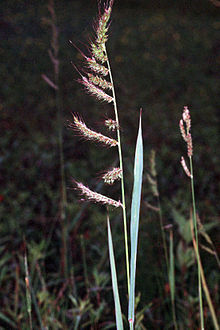

A specimen of Echinochloa crus-galli.

### Data

The data we are going to look at is available in the `CO2` dataset from **datasets** (a package that is part of the base R distribution). There are five variables:

**`Plant`**

an ordered factor giving a unique identifier for each plant

**`Type`**

a factor with levels giving the origin of the plant (Quebec or Mississippi)

**`Treatment`**

a factor indicating if the sample was chilled or not

**`conc`**

a numeric vector of ambient carbon dioxide concentrations (mL/L)

**`uptake`**

a numeric vector of carbon dioxide uptake rates (umol/m^2 sec)

The goal of the experiment was to investigate how carbon dioxide uptake is affected based on the ambient carbon dioxide concentration (`conc`), the origin of the plant `Type`, and `Treatment` (whether the plant was chilled overnight before the experiment started or not).

### Simple Scatter Plot

Let’s start basic and just look at a scatter plot of the uptake and ambient concentration. We’ll of course map uptake to the y axis, and concentration to the x axis. Before we get started, we’ll also rename some of the variables so that we get decent axis labels by default and change `Plant` from ordered to unordered (since the variable obviously isn’t ordinal). We’ll call the new dataset `co2`.

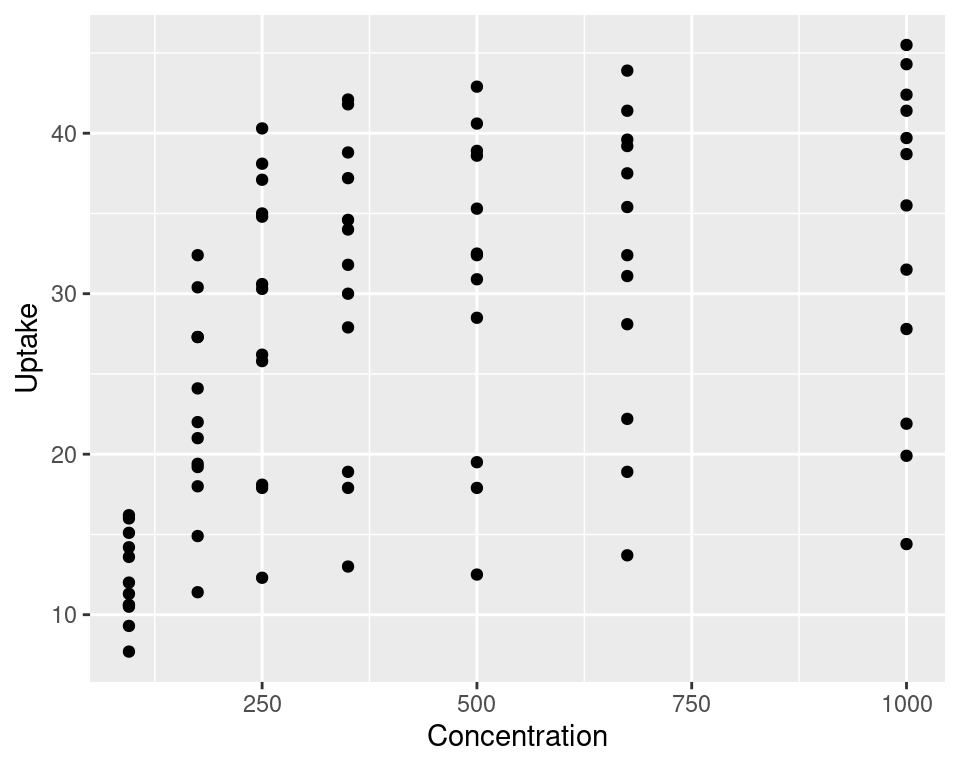

CO2 uptake and ambient CO2 concentration.

```r
library(tidyverse)

co2 <-
  CO2 %>%
  as_tibble() %>%
  rename(Concentration = conc,
         Origin = Type,
         Uptake = uptake) %>%
  mutate(Plant = factor(Plant, ordered = FALSE))

ggplot(co2, aes(Concentration, Uptake)) +
  geom_point()
```

### Adding Lines

Just using the point geom here is not a good design choice, however, since our data is in fact *matched* given that the observations belong to specific plants (and there are multiple measurements for each plant). There are several ways to show this. We could for instance use color, facets, or simply a line geom with mappings to the group aesthetic to fix this. We try the latter option here, but feel free to experiment with the other ideas as well.

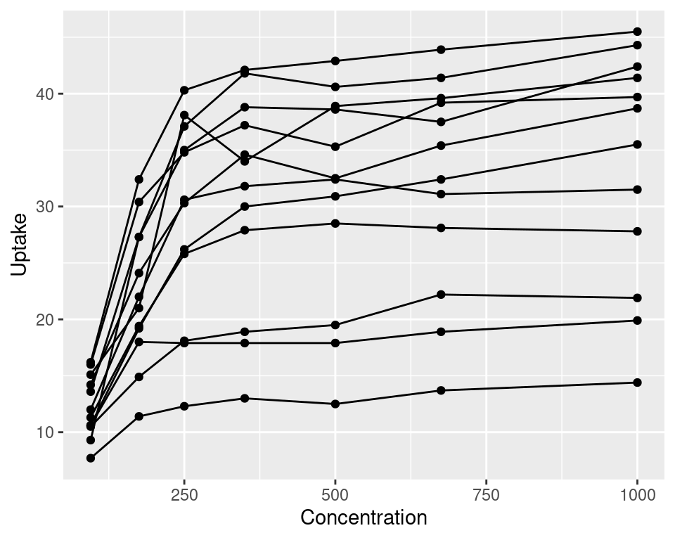

Ambient CO2 concentration and uptake for 12 plants in different conditions and from different origins.

```r
ggplot(co2, aes(Concentration, Uptake, group = Plant)) +
  geom_point() +
  geom_line()
```

Higher concentrations of CO2 clearly lead to higher uptake of the same, which of course isn’t surprising at all. What kind of relationship would you say this is? Take a moment to think about that.

### Does Overnight Cooling Matter?

We’ve yet to involve the other aspects of the experiment in our visualization, however, so let’s do that now. We begin by adding the cooling condition by mapping it to color. Also note that we here have a natural color mapping (blue to the cool condition), which we of course will take advantage of.

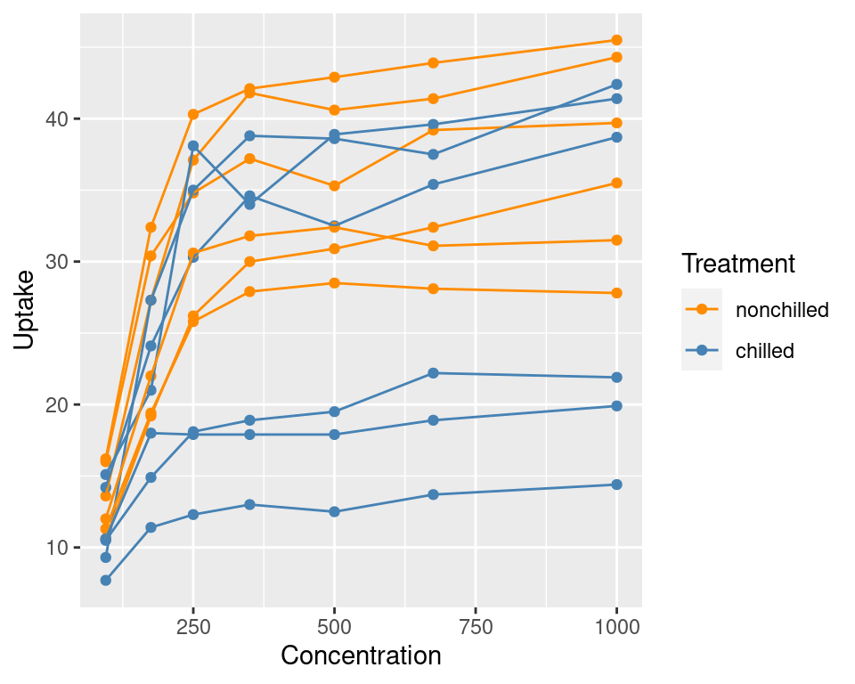

Ambient CO2 concentration and uptake for 12 plants under two different treatments (chilled overnight before the experiment or not).

```r
ggplot(co2, aes(Concentration, Uptake, group = Plant, color = Treatment)) +
  geom_point() +
  geom_line() +
  scale_color_manual(values = c("dark orange", "steel blue"))
```

### Plant Origin

It looks like uptake generally is improved in the non-chilled arm of the experiment but that there are two clear clusters here. Let’s see if the origin of the plants might serve to explain this bi-modal distribution.

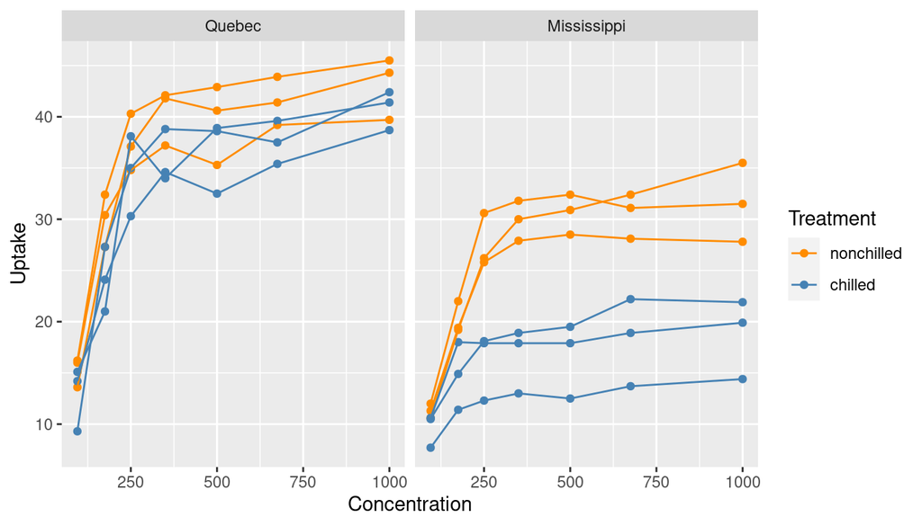

Ambient CO2 concentration and uptake for 12 plants under two different treatments (chilled overnight before the experiment or not) and from two different origins.

```r
ggplot(co2, aes(Concentration, Uptake, group = Plant, color = Treatment)) +
  geom_point() +
  geom_line() +
  facet_wrap("Origin") +
  scale_color_manual(values = c("dark orange", "steel blue"))
```

Yes, indeed it looks like the origin of the plants explain this exactly. We of course know that Mississippi is a much warmer state than Quebec is, so perhaps it makes sense that we see this adaptation in the plants in Quebec.

This example demonstrates how important it is to explore multivariate relationships, effectively *conditioning* your visualizations on some of the variables.

## Source Code

The source code for this document is available at https://github.com/stat-lu/STAE04/blob/master/worked-example-plants.Rmd.